# [R]영화를 통해 파악해보는 Titanic 분석

최의용

2020-04-25 10:17:43

[figure not shown]

Github Code: [Unfinishedgod](https://github.com/Unfinishedgod/Unfinishedgod.github.io/blob/master/docs/kaggle/Titanic_Machine_Learning_from_Disaster/titanic.Rmd)  
**Titanic 링크: [Titanic Data](https://www.kaggle.com/c/titanic/data)**

# 1 영화: 타이타닉

[figure not shown]

[figure not shown]

[figure not shown]

분석을 하기전에 당시의 시대 상황이 어떤지 파악해보자. 영화 타이타닉의 장면들을 가져와봤다. 장면들에서 볼수 있겠지만 우선 객실의 등급이 우선시 되는 시대였다. 1,2,3등급의 객실로 사람을 구분 짓고 보트에 탑승 할때도 되도록이면 1등급의 사람을 우선 태웠다. 심지어 영화내용에는 1등급의 사람들은 보트도 여유있게 탑승 한것처럼 표현을 하고 있더라. 그리고 나서 여자와 아이들을 먼저 태우려 하고, 결국 마지막에 죽는 사람들은 2,3등급 객실의 남자가 대부분 죽는것처럼 나온다. 캐글에서 받은 데이터도 실제로 이러한지 알아보면서 분석을 해보자.

# 2 패키지 불러오기&데이터 가져오기

```r
library(tidyverse)
library(ggplot2)
library(plotly)
library(rpart)
library(rpart.plot)
library(caret)
library(e1071)
library(randomForest)
library(patchwork)



training_set <- read.csv("train.csv")
test_set <- read.csv("test.csv")
```

# 3 탐색적 데이터 분석(EDA)

## 3.1 데이터 파악

각각의 데이터를 파악해보자. 영화에 표현되었던 객실(Pclass), 성별(Sex), 나이(Age)

```r
str(training_set)
```

```
## 'data.frame':    891 obs. of  12 variables:
##  $ PassengerId: int  1 2 3 4 5 6 7 8 9 10 ...
##  $ Survived   : int  0 1 1 1 0 0 0 0 1 1 ...
##  $ Pclass     : int  3 1 3 1 3 3 1 3 3 2 ...
##  $ Name       : Factor w/ 891 levels "Abbing, Mr. Anthony",..: 109 191 358 277 16 559 520 629 417 581 ...
##  $ Sex        : Factor w/ 2 levels "female","male": 2 1 1 1 2 2 2 2 1 1 ...
##  $ Age        : num  22 38 26 35 35 NA 54 2 27 14 ...
##  $ SibSp      : int  1 1 0 1 0 0 0 3 0 1 ...
##  $ Parch      : int  0 0 0 0 0 0 0 1 2 0 ...
##  $ Ticket     : Factor w/ 681 levels "110152","110413",..: 524 597 670 50 473 276 86 396 345 133 ...
##  $ Fare       : num  7.25 71.28 7.92 53.1 8.05 ...
##  $ Cabin      : Factor w/ 148 levels "","A10","A14",..: 1 83 1 57 1 1 131 1 1 1 ...
##  $ Embarked   : Factor w/ 4 levels "","C","Q","S": 4 2 4 4 4 3 4 4 4 2 ...
```

- PassengerID: 승객 고유번호
- Survived: 생존여부 0=No/ 1=Yes
- Pclass: 1등급, 2등급, 3등급
  - int형으로 되어있기에 **factor**형으로 변경필요
- Name: 승객명
  - factor형으로 되어있기에 **character**형으로 변경필요
- Sex: 성별
- Age: 나이
- SibSp: 함께 탑승한 배우자 또는 형제의 수
- Ticket: 티켓번호
  - factor형으로 되어있기에 **character**형으로 변경필요
- Fare: 티켓요금
- Cabin: 선실번호
  - factor형으로 되어있기에 **character**형으로 변경필요
- Embarked: 탑승한 곳 각각 “C”, “Q”, “S”는 탑승한 곳을 뜻하는 것으로 예상

```r
# Train set cleansing
training_set$Pclass <- as.factor(training_set$Pclass)
training_set$Name <- as.character(training_set$Name)
training_set$Ticket <- as.character(training_set$Ticket)
training_set$Cabin <- as.character(training_set$Cabin)

# Test set cleansing
test_set$Pclass <- as.factor(test_set$Pclass)
test_set$Name <- as.character(test_set$Name)
test_set$Ticket <- as.character(test_set$Ticket)
test_set$Cabin <- as.character(test_set$Cabin)

test_set$Age[is.na(test_set$Age)] <- mean(test_set$Age, na.rm = T)
```

## 3.2 데이터 Summary

Summary() 함수를 사용해서 데이터의 요약정보를 불러오자.

```r
summary(training_set)
```

```
##   PassengerId       Survived      Pclass      Name               Sex
##  Min.   :  1.0   Min.   :0.0000   1:216   Length:891         female:314
##  1st Qu.:223.5   1st Qu.:0.0000   2:184   Class :character   male  :577
##  Median :446.0   Median :0.0000   3:491   Mode  :character
##  Mean   :446.0   Mean   :0.3838
##  3rd Qu.:668.5   3rd Qu.:1.0000
##  Max.   :891.0   Max.   :1.0000
##
##       Age            SibSp           Parch           Ticket
##  Min.   : 0.42   Min.   :0.000   Min.   :0.0000   Length:891
##  1st Qu.:20.12   1st Qu.:0.000   1st Qu.:0.0000   Class :character
##  Median :28.00   Median :0.000   Median :0.0000   Mode  :character
##  Mean   :29.70   Mean   :0.523   Mean   :0.3816
##  3rd Qu.:38.00   3rd Qu.:1.000   3rd Qu.:0.0000
##  Max.   :80.00   Max.   :8.000   Max.   :6.0000
##  NA's   :177
##       Fare           Cabin           Embarked
##  Min.   :  0.00   Length:891          :  2
##  1st Qu.:  7.91   Class :character   C:168
##  Median : 14.45   Mode  :character   Q: 77
##  Mean   : 32.20                      S:644
##  3rd Qu.: 31.00
##  Max.   :512.33
##
```

## 3.3 결측치 파악

결측치를 파악해보자. 결측치가 177개이며 컬럼별로 파악해보면 다음과 같다.

```r
colSums(is.na(training_set))
```

```
## PassengerId    Survived      Pclass        Name         Sex         Age
##           0           0           0           0           0         177
##       SibSp       Parch      Ticket        Fare       Cabin    Embarked
##           0           0           0           0           0           0
```

Age 결측치를 처리하는데 있어서 여러가지 방법이 있는데, 그 중 대표적인 것들이 NA제거, 평균값으로 대치, 행,열 제거가 있습니다. 이번에는 NA를 제거 하려고 하는데, 이유는 다음과 같다.

- 결측치의 갯수가 그리 많지 않다.
- 나이데이터를 평균을 냈다가 177개의 평균값이 생존에 영향을 끼칠수도 있을까 싶다.

```r
training_set <- training_set %>%
  drop_na()
```

# 4 시각화

이번에는 데이터를 시각화해서 파악해보자. 여러 변수가 있지만 영화를 통해 파악해보기로 했기도 해서 성별, Pclass, 나이만 간단히 보자.

- 성별 -그래프를 보면 남자의 생존 비율이 여자보다 확실히 떨어지는것을 알 수 있다.
- 객실
  - 객실에 따라서도 사망자수는 꽤 차이를 볼 수 있다.
- 나이
  - 나이는 숫자형으로 되어 있어서 mutate(), case_when()함수를 사용해서 범주형 변수를 하나 만들었다. 10살 기준으로 끊어서 만들었으며, 특별한 이유는 없다. 그래프를 보면 10살 이하, 60살 이상은 적은 사망자수가 있는 반면, 20~50대에는 많은 사망자수가 있음을 볼 수 있다. 위에 게시한 타이타닉 영화 한장면만 봐도 어느정도는 알 수 있는 부분이다.

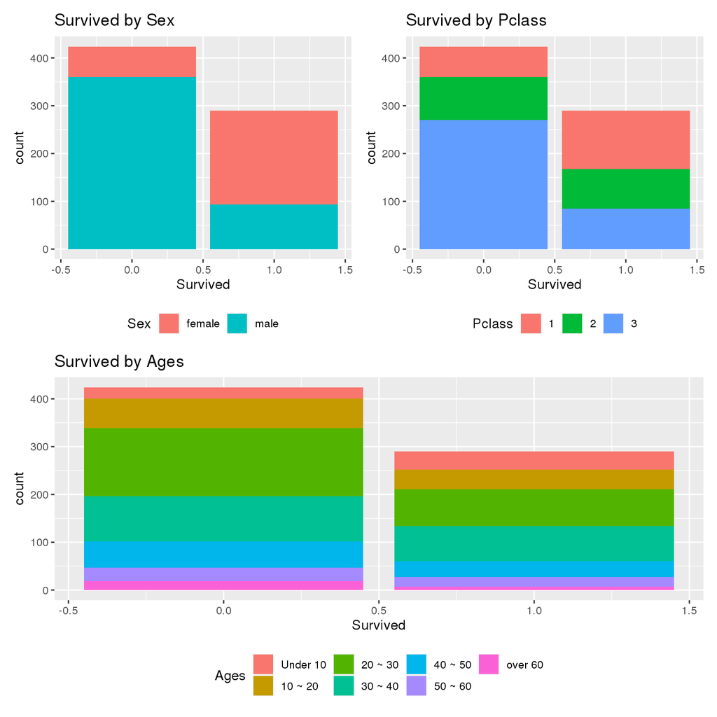

```r
training_set <- training_set %>%
  mutate(Ages = case_when(
    Age < 10 ~ "Under 10",
    Age < 20 ~ "10 ~ 20",
    Age < 30 ~ "20 ~ 30",
    Age < 40 ~ "30 ~ 40",
    Age < 50 ~ "40 ~ 50",
    Age < 60 ~ "50 ~ 60",
    TRUE ~ "over 60"
  ))

training_set$Ages <-
  factor(training_set$Ages,
         levels = c("Under 10", "10 ~ 20", "20 ~ 30", "30 ~ 40", "40 ~ 50", "50 ~ 60", "over 60"))

plot_1 <- ggplot(training_set, aes(x=Survived, fill = Sex)) +
  geom_bar() +
  ggtitle("Survived by Sex") +
  theme(legend.position="bottom")

plot_2 <- ggplot(training_set, aes(x = Survived, fill = Pclass)) +
  geom_bar() +
  ggtitle("Survived by Pclass") +
  theme(legend.position="bottom")

plot_3 <- training_set %>%
  ggplot(aes(x = Survived, fill = Ages)) +
  geom_bar() +
  ggtitle("Survived by Ages") +
  theme(legend.position="bottom")

(plot_1 + plot_2) / plot_3
```

# 5 모델: Random Forest

데이터 파악, 전처리, 시각화까지 모두 진행 했으니 이제 생존 예측을 해보자. 모델은 Random Forest를 사용할 것이며 캐글에서 유명한, xgboost, lightbgm만큼은 아니더라도 빠른 속도와, 적당히 높은 성능을 보이고 있다. 종속변수는 Survived, 독립변수는 Sex와 Pclass, age로 사용하려 한다.

```r
training_set$Survived <- as.factor(training_set$Survived)

# RandomForest 모델 생성
rf_m <- randomForest(Survived ~ Pclass + Age + Sex, data = training_set)
# importance
rf_info <- randomForest(Survived ~ Sex + Age + Pclass , data = training_set, importance = T)
```

## 5.1 결과해석

결과를 보면 성별, 객실, 나이 순으로 데이터의 중요도를 나타낸것을 볼 수 있다. 영화에 의존해서 데이터를 파악하다보니 꽤나 맘에 드는 순서가 나온것 같다.

```r
# 데이터의 중요도 확인
importance(rf_info)
```

```
##               0        1 MeanDecreaseAccuracy MeanDecreaseGini
## Sex    46.28124 60.26510             56.68094         85.02198
## Age    19.07316 15.04199             23.09609         20.22786
## Pclass 23.02133 26.91817             28.35001         34.43489
```

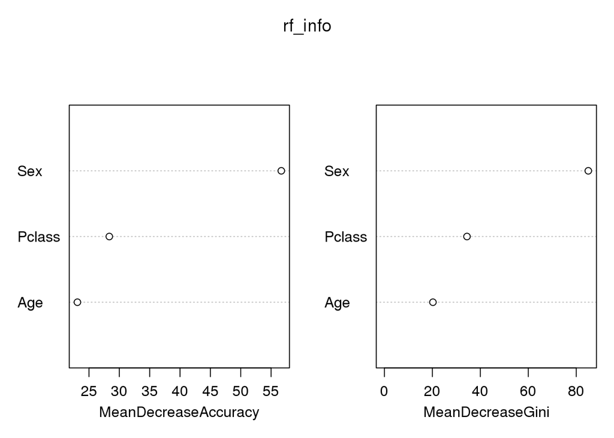

```r
#데이터의 중요도 시각화
varImpPlot(rf_info)
```

```r
# test 결과 확인
rf_p <- predict(rf_m, newdata=test_set, type="class")
```

# 6 제출 및 확인

랜덤포레스트로 분석해본 결과는 다음과 같다.

- Random Forest Score: 0.75598

```r
solution <- data.frame(PassengerID = test_set$PassengerId, Survived = rf_p)
write.csv(solution, "solution.csv", row.names = FALSE)
```

# 7 총평

캐글에서 타이타닉을 하려는데 문득 영화가 생각이 났었다. 그래서 영화의 내용을 기반으로 분석을 해보면 어떨까? 하는 생각으로 가볍게 분석을 시도해봤다. 상당히 간단하게 진행을 했지만 다른 타이타닉 분석글들을 보면 높은 수준의 글들이 있는걸 볼 수 있는데, 다음에는 이러한 것들을 많이 필사 해가면서 수준을 높혀야 겠다.